# Football Performance Insights

Analisis estadistico de rendimiento y scouting con StatsBomb Open Data

Dramirezm02

25/06/2026

# Resumen ejecutivo

Este reporte presenta un analisis de rendimiento del partido **Spain 2-1 England**, jugado el **2024-07-14**, usando datos abiertos de eventos de StatsBomb.

El objetivo es mostrar una pieza de portafolio alineada con roles de **datos e insights de futbol**: limpieza de datos, metricas deportivas, visualizacion tactica y recomendaciones accionables.

El reporte combina tres niveles de analisis:

- **Estadistica descriptiva:** tiros, goles, pases, precision, acciones defensivas y conducciones.
- **Metricas futbolisticas intermedias:** xG, mapas de tiro, pases progresivos y acciones por zona.
- **Estadistica avanzada:** modelo Poisson, simulacion Monte Carlo, probabilidades de resultado y ranking ponderado de scouting.

Indicadores principales por equipo

| team | shots | xg | goals | passes | pass_completion_pct | defensive_events | carries |
| --- | --- | --- | --- | --- | --- | --- | --- |
| Spain | 16 | 1.792 | 2 | 592 | 87.5 | 233 | 490 |
| England | 9 | 0.726 | 1 | 323 | 78.6 | 236 | 267 |

# Lectura del partido

```
## **Spain** genero el mayor volumen ofensivo: 16 tiros y 1.792 xG. Su precision de pase fue de 87.5%, frente a 78.6% del rival.
```

# Modelo probabilistico

El modelo usa el **xG de cada equipo como parametro lambda** de una distribucion Poisson. Esto no reemplaza un modelo predictivo entrenado con muchos partidos, pero permite convertir el volumen y calidad de ocasiones del partido en una lectura probabilistica clara.

Parametros lambda usados por el modelo Poisson

| team | lambda_xg |
| --- | --- |
| Spain | 1.792 |
| England | 0.726 |

## Probabilidades de resultado

Probabilidades de resultado con modelo Poisson

| result | probability_pct |
| --- | --- |
| Spain win | 62.8 |
| Draw | 22.6 |
| England win | 14.7 |

## Simulacion Monte Carlo

Se simularon 10.000 partidos usando los xG observados como media esperada de goles para cada equipo.

Probabilidades de resultado con simulacion Monte Carlo

| result | simulations | probability_pct |
| --- | --- | --- |
| Spain win | 6256 | 62.6 |
| Draw | 2296 | 23.0 |
| England win | 1448 | 14.5 |

## Marcadores mas probables

Marcadores mas probables

| scoreline | result | probability_pct |
| --- | --- | --- |
| 1-0 | Spain win | 14.5 |
| 2-0 | Spain win | 13.0 |
| 1-1 | Draw | 10.5 |
| 2-1 | Spain win | 9.4 |
| 0-0 | Draw | 8.1 |
| 3-0 | Spain win | 7.8 |
| 0-1 | England win | 5.9 |
| 3-1 | Spain win | 5.6 |

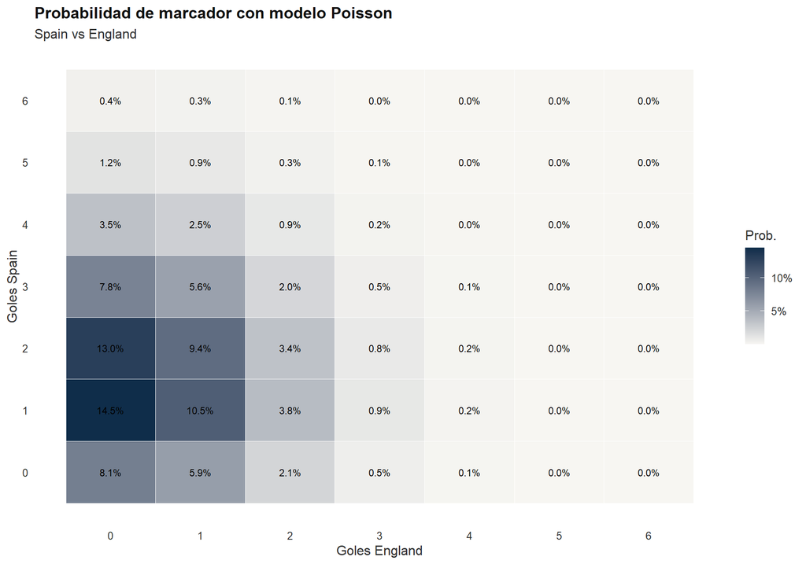

# Analisis ofensivo

## Mapa de tiros

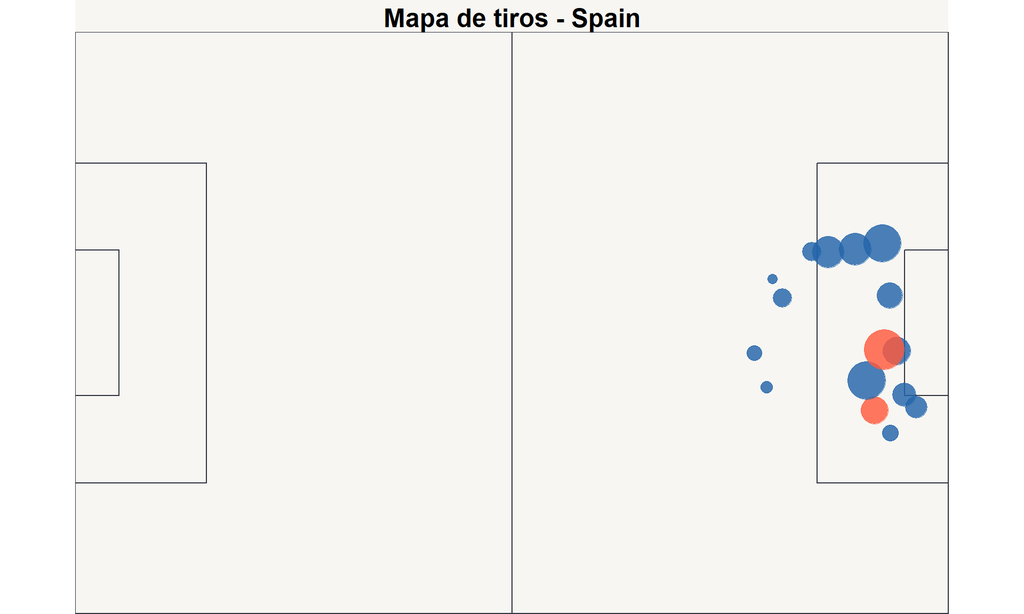

## Pases progresivos

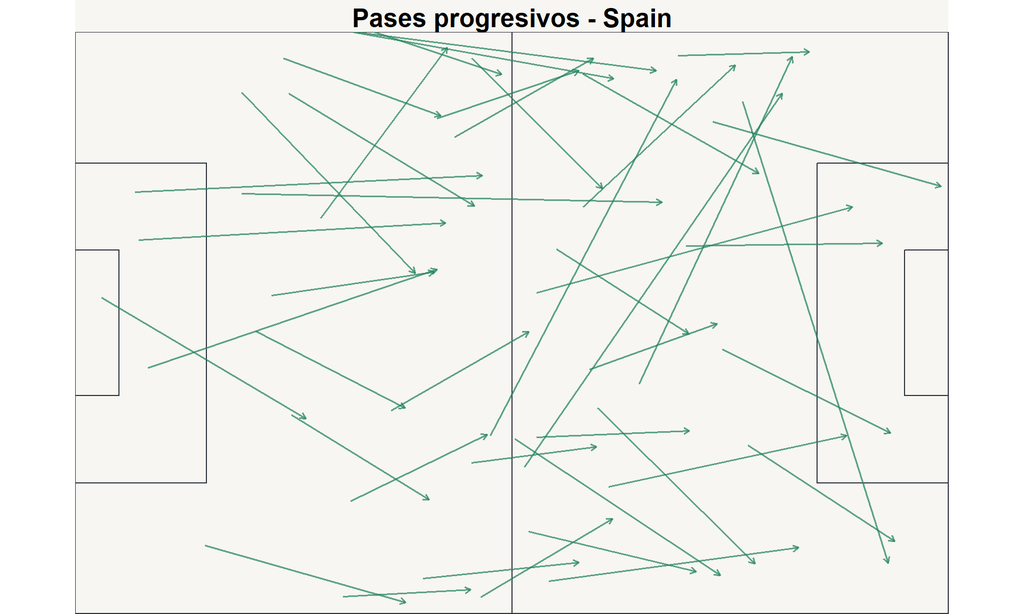

# Analisis defensivo

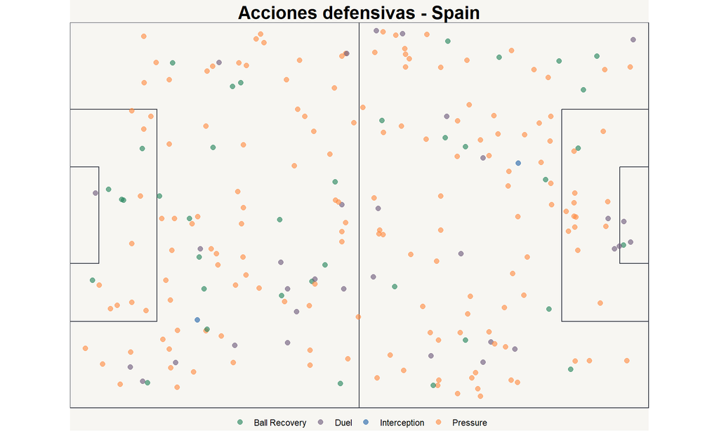

# Scouting inicial

Ranking avanzado de jugadores - Spain

| player | position | scouting_score | xg | progressive_passes | progressive_carries | pressures | recoveries | pass_completion_pct |
| --- | --- | --- | --- | --- | --- | --- | --- | --- |
| Daniel Olmo Carvajal | Center Attacking Midfield | 60.3 | 0.272 | 3 | 1 | 26 | 3 | 78.8 |
| Nicholas Williams Arthuer | Left Wing | 60.0 | 0.230 | 2 | 7 | 17 | 5 | 80.4 |
| Lamine Yamal Nasraoui Ebana | Right Wing | 59.1 | 0.326 | 5 | 1 | 19 | 0 | 66.7 |
| Álvaro Borja Morata Martín | Center Forward | 55.2 | 0.347 | 0 | 0 | 23 | 3 | 71.4 |
| Aymeric Laporte | Left Center Back | 54.7 | 0.098 | 10 | 12 | 2 | 0 | 96.4 |
| Fabián Ruiz Peña | Left Defensive Midfield | 51.8 | 0.081 | 8 | 1 | 18 | 7 | 87.3 |
| Robin Aime Robert Le Normand | Right Center Back | 51.2 | 0.117 | 10 | 6 | 1 | 4 | 95.2 |
| Daniel Carvajal Ramos | Right Back | 40.6 | 0.000 | 8 | 1 | 15 | 5 | 86.3 |
| Mikel Oyarzabal Ugarte | Center Forward | 34.4 | 0.321 | 0 | 0 | 6 | 1 | 75.0 |
| Marc Cucurella Saseta | Left Back | 28.0 | 0.000 | 5 | 0 | 15 | 1 | 97.7 |
| Unai Simón Mendibil | Goalkeeper | 21.5 | 0.000 | 8 | 0 | 0 | 5 | 85.0 |
| Rodrigo Hernández Cascante | Right Defensive Midfield | 18.7 | 0.000 | 1 | 1 | 11 | 2 | 90.6 |

## Radar del jugador mejor rankeado

El radar combina cinco dimensiones normalizadas de 0 a 100: xG, progresion, defensa, involucramiento y score general de scouting.

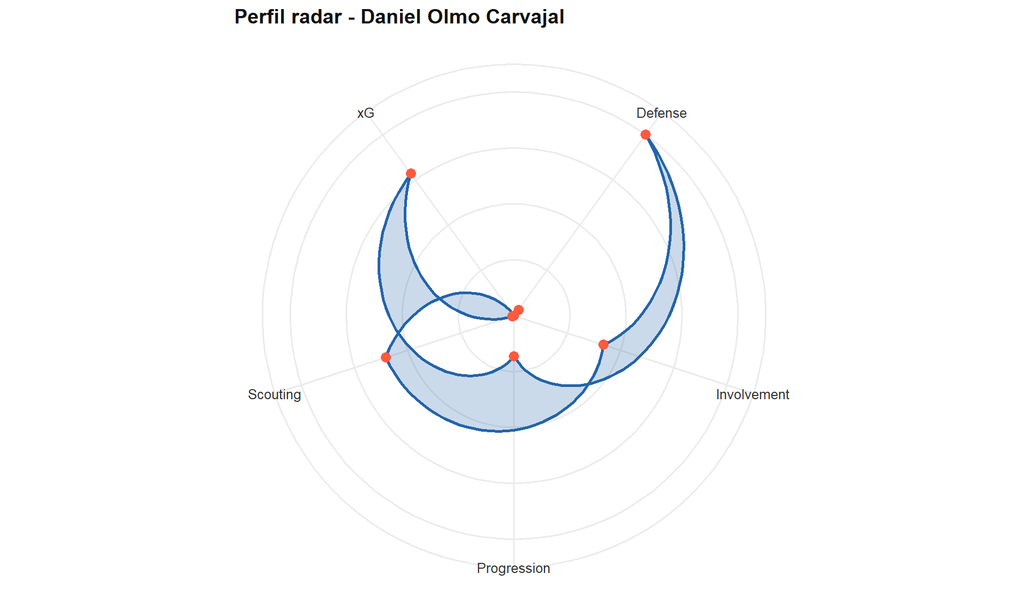

# Recomendaciones deportivas

- Priorizar el analisis de las zonas de finalizacion donde el equipo acumula mayor xG.
- Revisar los jugadores con mas pases progresivos para identificar rutas de avance repetibles.
- Cruzar presiones, recuperaciones e intercepciones para evaluar la agresividad tras perdida.
- El equipo genero mas peligro que el rival; conviene profundizar en los mecanismos ofensivos que produjeron esas ventajas.
- Para scouting, convertir estas metricas a valores por 90 minutos y comparar jugadores por posicion.
- Para modelado, usar el Poisson y Monte Carlo como capa explicativa inicial; el siguiente paso seria entrenar con una muestra historica de partidos.

# Datos y reproducibilidad

Fuente: [StatsBomb Open Data](https://github.com/statsbomb/open-data).

El proyecto completo incluye:

- Dashboard Shiny en `app.R`.
- Scripts de descarga y limpieza en `R/`.
- Reporte reproducible en `reports/football_performance_report.Rmd`.
- HTML publicable en `docs/index.html`.